# Supplementary Information

Authors

Nicholas C Wu

Tomás Villada-Cadavid

Christopher Turbill

Published

15th Oct 2025

[GitHub Repository](https://github.com/nicholaswunz/bat-resp): The Quarto code to produce the HTML file can be downloaded from the *Code* drop-down menu (top right).

This supplementary file contains the *R* workflow for processing and analysing the raw data, and creating figures for the manuscript titled “**Local climate and genetic influence on intraspecific patterns in torpor physiology of a cave-roosting bat**”.

# Supplementary Methods

## Respirometry set-up

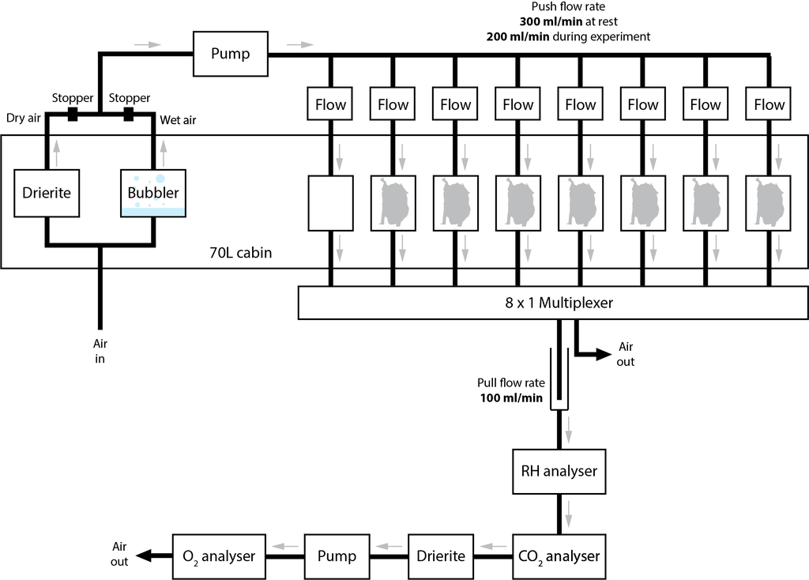

**Fig. S1** | Schematic diagram of the flow-through respirometry set up to measure oxygen consumption, carbon dioxide production, and evaporative water loss of seven torpored *Miniopterus orianae oceanensis* and one control blank chamber. The mass flow controllers were placed outside the temperature-controlled incubator to change the flow rate during the experiment manually.

## Calculations and conversation

The rate of oxygen consumption ($\dot{V}\textrm{O}_2$; ml O<sub>2</sub> min<sup>-1</sup>) was calculated following Lighton (2019) in Equation 1:

$$\dot{V}\textrm{O}_2 = \frac{\textrm{FR}^\textrm{'}_{\textrm{i}}[(F_{\textrm{i}}\textrm{O}_{2}-F_{\textrm{e}}\textrm{O}_{2})-F_{\textrm{e}}\textrm{O}_{2}(F^\textrm{'}_{\textrm{e}}\textrm{CO}_{2}-F^\textrm{'}_{\textrm{i}}\textrm{CO}_{2})]}{(1-F_{\textrm{e}}\textrm{O}_{2})}
\tag{1}$$

where $\textrm{FR}^\textrm{'}_{\textrm{i}}$ is the incurrent dry flow rate corrected for water vapour ($\textrm{FR}^\textrm{'}_{\textrm{i}} = \textrm{FR}_{\textrm{i}} \times \textrm{BP}/(\textrm{BP}-\textrm{WVP})$). $F_{\textrm{i}}\textrm{O}_{2}$ and $F_{\textrm{e}}\textrm{O}_{2}$ is the dry incurrent (baseline) and excurrent O<sub>2</sub> gas concentration, respectively. $F^\textrm{'}_{\textrm{e}}\textrm{CO}_{2}$ and $F^\textrm{'}_{\textrm{i}}\textrm{CO}_{2}$ is the dry” equivalent of the excurrent and incurrent CO2 gas concentration corrected for water vapour, respectively. The rate of carbon dioxide production ($\dot{V}\textrm{CO}_2$; ml CO<sub>2</sub> min<sup>-1</sup>) was calculated as Equation 2:

$$\dot{V}\textrm{CO}_2 = \frac{\textrm{FR}^\textrm{'}_{\textrm{i}}[(F^\textrm{'}_{\textrm{e}}\textrm{CO}_{2}-F^\textrm{'}_{\textrm{i}}\textrm{CO}_{2})-F^\textrm{'}_{\textrm{e}}\textrm{CO}_{2}(F_{\textrm{i}}\textrm{O}_{2}-F_{\textrm{e}}\textrm{O}_{2})]}{(1-F^\textrm{'}_{\textrm{e}}\textrm{CO}_{2})}
\tag{2}$$

Metabolic rate (MR; kJ h<sup>-1</sup>) was calculated from $\dot{V}\textrm{O}_2$ and $\dot{V}\textrm{CO}_2$ as Equation 3:

$$\textrm{MR} = 0.06 \times (3.941 \times \dot{V}\textrm{O}_2 + 1.106 \times \dot{V}\textrm{CO}_2) \times 4.184
\tag{3}$$

The evaporative water loss (EWL) or $\dot{V}\textrm{H}_2\textrm{O}$ (µg H2O min<sup>-1</sup>) was calculated as Equation 4:

$$\dot{V}\textrm{H}_2\textrm{O} = \textrm{FR}_{\textrm{i}} \left( \frac{\textrm{WVP}}{T \times R_{\textrm{w}}} \right)
\tag{4}$$

where WVP is the water vapour pressure (kPa) minus the baseline WVP, $T$ is temperature in Kelvin (°C + 273.15), and $R_{\textrm{w}}$ is the gas constant for water vapour (461.5 J kg<sup>−1</sup> K<sup>−1</sup>). $\dot{V}\textrm{H}_2\textrm{O}$ was converted to mg H<sub>2</sub>O h<sup>-1</sup> by multiplying by 0.06. Prior to calculating $\dot{V}\textrm{O}_2$, $\dot{V}\textrm{CO}_2$, and $\dot{V}\textrm{H}_2\textrm{O}$, the baseline drift and time lag of the fractional gas concentrations were corrected for.

## Cave microclimate

The local air temperature and relative humidity outside and inside the cave was recorded to monitor differences in microclimate conditions available for cave-roosting bats. An external HOBO logger (MX2302A; Onset, MA, USA) mounted with a radiation shield (RS3-B; Onset) was placed outside ~20 m away at 1.5 m height from the cave entrance to log external microclimate at 30 second intervals. An internal HOBO logger (MX2301A; Onset) was placed inside the cave above ground in the same chamber where bats were observed roosting to log cave microclimate at 30 second intervals. Cave surface temperature and relative humidity was measured with an infrared thermometer (TG56 IR 30:1; FLIR, OR, USA) and HOBO logger on an 8 m extendable pole (MX2302A) every 10 m inside the cave or where bats were found. Cave surface temperature were measured in three replicates at three time points, May, July, and September. Vapour pressure deficit (kPa) was calculated as the difference between the saturation water vapour pressure ($e_s$) and the actual water vapour pressure ($e_a$). $e_s$ was calculated following the Clausius-Clapeyron equation (Stull, 2000).

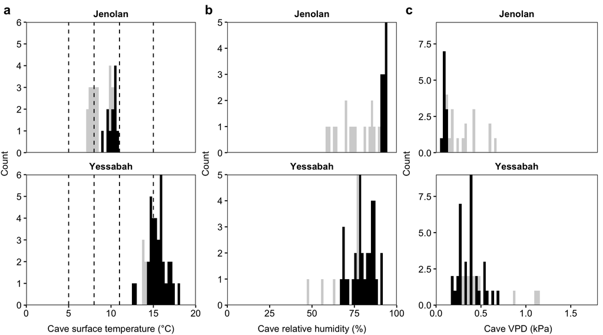

**Fig. S2** | Distribution of measured (**a**) cave surface temperatures (°C), (**b**) cave relative humidity (RH; %), and (**c**) calculated cave vapour pressure deficit (VPD; kPa) from Jenolan and Yessabah during the 2023 Austral winter and early spring period (May–September). Surface temperature, RH, and VPD with bats present were coloured **black**, while surface temperature, RH, and VPD without bats present were coloured **grey**. Dashed lines represented the experimental exposure temperatures which are within the expected temperature range in the caves.

# Process Data

Metadata of the imported respirometry data for analysis.

| Name | Description |
| --- | --- |
| pop | Unique identifier of population source (Jenolan, Yessabah). |
| date_exp | The date when the experiment was conducted in day/month/year |
| ID | Unique identifier of the individual. |
| ID_gene | Unique identifier of the biopsy sample for genetic analysis |
| sex | Sex of the individual (female, male) |
| FA_mm | Forearm length in millimetre (mm). |
| mass_g | Body mass in grams (g). |
| temp_exp | Set air temperature exposure in degrees Celcius (°C). |
| temp_act | Recorded air temperature in degrees Celcius (°C). |
| RH_treatment | Recorded relative humidity in percentage (%). |
| chamber_n | Unique identifier of the metabolic chamber |
| setFR_ml_min | Set flow rate (ml/min). |
| BP_kPa | Recorded barometric pressure (kPa). |
| FR_adj_ml_min | Adjusted-flow rate (ml/min). |
| T_start | Start time of the respirometry measurments as year-month-day hour:min:sec. |
| T_end | End time of the respirometry measurments as year-month-day hour:min:sec. |
| t_tor_h | Time between onset of torpor and respirometry measurments. |
| VO2_ml_min | Calculated rate of oxygen consumption in millilitres per minute (ml/min). |
| VCO2_ml_h | Calculated rate of carbon dioxide production in millilitres per minute (ml/min). |
| EWL_mg_h | Calculated rate of evaporative water loss in milligrams per minute (mg/h). |
| Tsk_C | Calculated skin surface temperature in degrees Celcius (°C). |
| VO2_ml_h | Calculated rate of oxygen consumption in millilitres per hour (ml/h). |
| VCO2_ml_h | Calculated rate of carbon dioxide production in millilitres per hour (ml/h). |
| VO2_ml_g_h | Mass-specific oxygen consumption in ml/g/h. |
| VCO2_ml_g_h | Mass-specific carbon dioxide production in ml/g/h. |
| EWL_mg_g_h | Mass-specific evaporative water loss in mg/g/h. |
| lnMass | The natural logarithm of body mass. |
| MR_kJ_h | Calculated metabolic rate in kilojoules per hour (kJ/h). |
| MR_J_h | Calculated metabolic rate in joules per hour (J/h). |
| MR_W | Calculated metabolic rate in Watts (W). |
| MR_mW | Calculated metabolic rate in milliWatts (mW). |
| t_diff | Difference between skin temperature and actual air temperature in degrees Celcius (°C). |

## Load and clean data

Load and clean the raw data for analysis. **Table S1** summarises data on torpor physiology traits by site, sex, and temperature exposure.

```r
# Respirometry data
resp_dat <- read.csv(file.path(data_path, "data/resp_raw_dat.csv")) %>%
  dplyr::select(-c(file_name, FR_ml_min, transmitter_n, freq_hz)) %>%
  dplyr::filter(cond == "dry" & ID != c("MAM-18", "MAM-16")) %>% # remove individuals not in torpor
  dplyr::mutate(pop         = factor(pop),
                VO2_ml_h    = VO2_ml_min * 60,
                VCO2_ml_h   = VCO2_ml_min * 60,
                VO2_ml_g_h  = VO2_ml_h / mass_g,
                VCO2_ml_g_h = VCO2_ml_h / mass_g,
                EWL_mg_g_h  = EWL_mg_h / mass_g,
                lnMass      = log(mass_g),
                T_start     = lubridate::dmy_hm(T_start),
                T_end       = lubridate::dmy_hm(T_end),
                MR_kJ_h     = (0.06 * (3.941 * VO2_ml_min + 1.106 * VCO2_ml_min)) * 4.184, # Convert VO2 and VCO2 to MR kJ h
                MR_J_h      = MR_kJ_h * 1000,
                MR_W        = MR_kJ_h * 0.2777777778, # convert to Watt
                MR_mW       = MR_W * 1000,
                lnVO2       = log(VO2_ml_h),
                lnVCO2      = log(VCO2_ml_h),
                lnMR        = log(MR_J_h),
                lnEWL       = log(EWL_mg_h),
                t_diff      = Tsk_C - temp_act)

# filter torpor data only
torpor_dat <- resp_dat %>%
  dplyr::filter(Tsk_C < 28)

resp_sum <- torpor_dat %>%
  dplyr::group_by(pop, temp_exp) %>%
  dplyr::summarise(n         = length(VO2_ml_h),
                   EWL_mean  = mean(EWL_mg_h, na.rm = T),
                   EWL_sd    = sd(EWL_mg_h, na.rm = T),
                   Tsk_mean  = mean(Tsk_C, na.rm = T),
                   Tsk_sd    = sd(Tsk_C, na.rm = T),
                   MR_mean   = mean(MR_kJ_h, na.rm = T),
                   MR_sd     = sd(MR_kJ_h, na.rm = T)
                   )
```

| Site | *T*<sub>a</sub> (°C) | *n* | Sex | Mass (g) | $\dot{V}\textrm{O}_2$ (ml h<sup>-1</sup>) | $\dot{V}\textrm{CO}_2$ (ml h<sup>-1</sup>) | TMR (J h<sup>-1</sup>) | TEWL (mg h<sup>-1</sup>) | *T*<sub>sk</sub> (°C) |
| --- | --- | --- | --- | --- | --- | --- | --- | --- | --- |
| Jenolan | 5 | 4 | female | 13.68 | 2.37±1.43 | 2.05±1.20 | 48.61±29.10 | 4.31±1.45 | 15.48±1.49 |
| Jenolan | 5 | 3 | male | 14.27 | 2.66±1.94 | 2.26±1.76 | 54.39±40.20 | 4.35±1.31 | 16.67±0.51 |
| Jenolan | 8 | 4 | female | 13.68 | 3.27±2.02 | 2.93±1.98 | 67.55±42.53 | 4.80±0.74 | 16.93±2.60 |
| Jenolan | 8 | 3 | male | 14.27 | 4.13±2.50 | 3.61±2.20 | 84.86±51.28 | 4.92±1.08 | 17.67±0.19 |
| Jenolan | 11 | 6 | female | 14.03 | 6.42± 6.36 | 6.08±6.13 | 133.98±133.17 | 5.01±1.04 | 18.65±2.26 |
| Jenolan | 11 | 5 | male | 14.40 | 13.35±10.07 | 11.89±9.86 | 275.17±211.41 | 11.46±5.31 | 20.23±3.09 |
| Jenolan | 15 | 6 | female | 13.62 | 19.95±18.51 | 16.52±14.75 | 405.40±373.30 | 13.75±6.54 | 21.24±2.58 |
| Jenolan | 15 | 5 | male | 14.40 | 24.33±14.73 | 21.05±12.32 | 498.53±299.35 | 21.67±9.04 | 23.35±2.28 |
| Yessabah | 5 | 7 | female | 13.26 | 0.72±0.33 | 0.69±0.30 | 15.01± 6.82 | 3.37±0.67 | 14.97±0.46 |
| Yessabah | 5 | 8 | male | 15.19 | 1.65±0.68 | 1.54±0.63 | 34.27±14.15 | 3.79±0.31 | 15.19±0.39 |
| Yessabah | 8 | 7 | female | 13.26 | 1.19±0.48 | 1.15±0.49 | 24.98±10.19 | 3.83±0.49 | 16.10±0.44 |
| Yessabah | 8 | 8 | male | 15.19 | 2.22±1.17 | 2.07±1.13 | 46.23±24.47 | 6.31±3.68 | 16.05±0.53 |
| Yessabah | 11 | 7 | female | 13.26 | 1.77±0.90 | 1.67±0.84 | 36.99±18.73 | 5.31±1.84 | 17.13±0.31 |
| Yessabah | 11 | 8 | male | 15.19 | 2.61±1.37 | 2.43±1.35 | 54.32±28.73 | 9.42±5.70 | 17.27±0.46 |
| Yessabah | 15 | 7 | female | 13.26 | 3.75±2.05 | 3.40±1.74 | 77.56±41.80 | 21.54±6.12 | 20.42±1.91 |
| Yessabah | 15 | 8 | male | 15.19 | 3.43±1.68 | 3.18±1.58 | 71.37±34.82 | 23.46±6.89 | 19.65±0.52 |